# Obligationsafkast

Hvad tjente vi — og hvorfor?

Niklas Lehmann Jensen

#### Dagens spørgsmål

- Hvordan måles en obligationsinvestors afkast korrekt med **dirty prices** og betalinger?
- Hvorfor er effektiv rente ikke det samme som **realiseret afkast**?
- Hvordan omsætter Babcock **varighed og renteforventning** til horisontafkast?
- Hvordan forklarer FIPA, **hvor afkastet kom fra**?

#### Læringsmål

- Beregne realiseret og forventet **holding-period return**
- Skelne mellem effektiv rente, forventet afkast og realiseret afkast
- Anvende **Babcocks formel** og et break-even renteskift
- Fortolke carry, roll-down, kurve, OAS, volatilitet og prepayment
- Vurdere om et afkast passer til den risiko, investor troede, der blev taget

## Fra pris til afkast

#### Afkast er et lukket system

[figure not shown]

#### Holding-period return bruger dirty prices

$$HPR_{0,h}=\frac{K_h^{dirty}+FV_h(CF)-K_0^{dirty}}{K_0^{dirty}}$$

**Definition**

$K_t^{dirty}=K_t^{clean}+v_t$

- Køb: faktisk betalt **dirty** startværdi
- Undervejs: alle betalinger og evt. geninvestering
- Salg: faktisk modtaget **dirty** slutværdi

$$HPR_{0,h}^{ann}=(1+HPR_{0,h})^{1/h}-1$$

#### Et realiseret halvårsafkast

| Tidspunkt | Clean | Vedhængende rente | Dirty / betaling |
| --- | --- | --- | --- |
| Køb, 3 mdr. før termin | 102,50 | 3,00 | **105,50** |
| Kupon ved termin | — | — | **+4,00** |
| Salg, 3 mdr. efter termin | 102,50 | 1,00 | **103,50** |

$$HPR_{0,h}=\frac{103{,}50+4{,}00-105{,}50}{105{,}50}=1{,}90\%$$

$$HPR_{0,h}^{ann}=(1+0{,}01896)^2-1=\mathbf{3{,}83\%\ p.a.}$$

#### Forventet afkast kræver en exit-antagelse

$$K_h^{clean}=P_h\!\left(CF_{h+1},\ldots,CF_T;\,y_h\right)$$

- Fastlæg cash flows frem til horisonten og deres reinvesteringsrente
- Prisfastsæt de resterende cash flows med en forventet **exit-rente**
- For en konverterbar obligation kræver exit-kursen modellerne fra kapitel 6–7

**Indsigt**

I noternes 10-årige statseksempel giver $y_h=3{,}35\%$ en forventet clean exit-kurs på **105,447**.

#### Effektiv rente er et prisningsmål

| Begreb | Spørgsmål | Hvad kræves? |
| --- | --- | --- |
| Effektiv rente | Hvilken konstant rente matcher prisen? | Kendte cash flows og geninvestering til samme rente |
| Forventet horisontafkast | Hvad forventer vi frem til $h$? | Exit-kurs, cash flows og reinvestering |
| Realiseret afkast | Hvad skete faktisk? | Faktiske dirty priser og betalinger |

**Advarsel**

En høj effektiv rente garanterer ikke et højt realiseret afkast.

## Renteforventning og horisont

#### Babcock kobler varighed til horisontafkast

$$HPR_{0,h}^{ann}\approx y_0+\left(1-\frac{D_{Mac,0}}{h}\right)\Delta y$$

**$D_{Mac}>h$**  
Kurseffekten dominerer

**$D_{Mac}=h$**  
Effekterne balancerer

**$D_{Mac}<h$**  
Geninvestering dominerer

**Indsigt**

For lange obligationer og korte horisonter er en rentestigning normalt dårlig for horisontafkastet.

#### Ti basispoint kan flytte afkastet markant

- Købsrente $y_0=3{,}00\%$
- Macaulay-varighed $D_{Mac,0}=9{,}05$ år
- Horisont $h=273/365=0{,}748$ år
- Rentestigning $\Delta y=+0{,}10\%=+10$ bp

$$HPR^{ann}\approx0{,}0300+\left(1-\frac{9{,}05}{0{,}748}\right)0{,}0010=\mathbf{1{,}89\%}$$

#### Break-even gør et rentesyn testbart

$$\Delta y^*=\frac{h(y_A-y_B)}{D_A-D_B}$$

| Obligation | $y$ | $D_{Mac}$ | $-50$ bp | $0$ bp | $+50$ bp | Break-even mod A |
| --- | --- | --- | --- | --- | --- | --- |
| A | 2,10 % | 1,20 | 2,80 % | 2,10 % | 1,40 % | — |
| B | 2,25 % | 4,90 | 6,65 % | 2,25 % | −2,15 % | +2 bp |
| C | 2,85 % | 6,80 | 9,15 % | 2,85 % | −3,45 % | **+7 bp** |
| D | 3,30 % | 9,80 | 12,60 % | 3,30 % | −6,00 % | +7 bp |

## Hvor kom afkastet fra?

#### Første snit: carry og markedsværdi

$$HPR_{0,h}=HPR_{0,h}^{carry}+HPR_{0,h}^{markedsværdi}$$

- **Carry:** betalinger, rentetilskrivning og finansiering
- **Markedsværdi:** ændringen i obligationens kurs

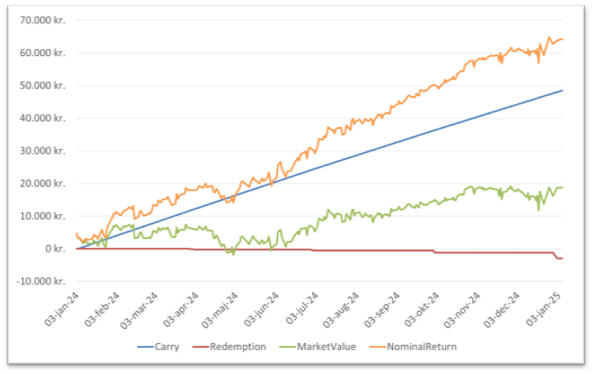

#### FIPA forklarer drivkræfterne

$$\Delta P\approx\Delta P^{roll}+\Delta P^{kurve}+\Delta P^{OAS}+\Delta P^{vol}+\Delta P^{prepay}$$

| Komponent | Spørgsmål den besvarer |
| --- | --- |
| Carry | Hvad tjente vi ved at eje og modtage betalinger? |
| Roll-down | Hvad skete, fordi obligationen blev kortere? |
| Kurve | Hvad skete, fordi rentekurven flyttede sig? |
| OAS | Blev obligationen dyrere eller billigere relativt til kurven? |
| Volatilitet | Ændrede værdien af den indbyggede option sig? |
| Prepayment | Ændrede de forventede cash flows sig? |

#### Et positivt afkast kan skjule negative drivere

$$HPR_{0,h}=\frac{103+2-102}{102}=\mathbf{2{,}94\%}$$

| Komponent | Kurspoint |
| --- | --- |
| Carry | +2,00 |
| Roll-down | +0,30 |
| Kurve | −0,80 |
| OAS | +1,20 |
| Volatilitet | −0,20 |
| Prepayment | +0,50 |
| **Samlet værdiændring** | **+3,00** |

**Indsigt**

Markedsværdibidragene summer til +1,00; sammen med carry på +2,00 afstemmer de til +3,00 kurspoint.

## Hvad skete i 2024?

#### Samme marked gav mange afkastmotorer

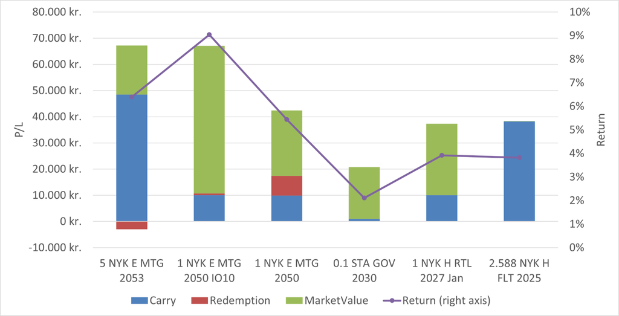

#### To produkter — to forskellige forklaringer

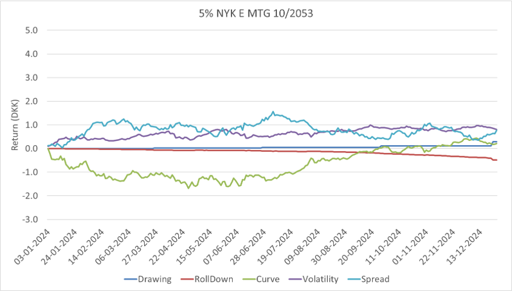

**5 % NYK E MTG 2053**

- Lang, konverterbar: kurve, OAS, volatilitet og prepayment

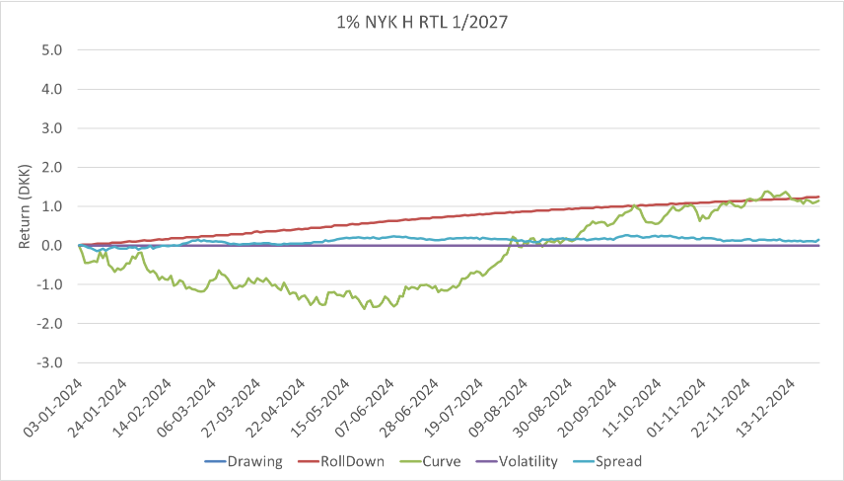

**1 % NYK H RTL 2027**

- Kort, inkonverterbar: korte renter, roll-down og spænd

#### The Takeaways

1. Mål afkast med **dirty startværdi, betalinger og dirty slutværdi**.
2. Effektiv rente er et prisningsmål; realiseret afkast afhænger også af exit-kurs, geninvestering og cash flows.
3. Babcock og break-even oversætter varighed og renteforventning til horisontafkast.
4. FIPA forklarer afkastet gennem carry, roll-down, kurve, OAS, volatilitet og prepayment.

## Øvelser

#### Øvelser: mål horisontafkastet

1. **HPR:** En 4 % obligation købes 90 dage før termin til clean 101,40, kuponen modtages, og den sælges 90 dage efter termin til samme clean kurs. Beregn dirty priser, HPR og annualiseret afkast.
2. **Clean/dirty:** Nominelt 1 mio. kr., 4 % årlig kupon og valør 120 dage efter termin. Beregn vedhængende rente i kroner og kurspoint.
3. **Forventet HPR:** Dirty køb 98,50, kupon 2,00 og dirty exit 99,20 efter ét år. Beregn HPR og gentag med exit 97,80.

#### Øvelser: test og forklar afkastet

4. **Babcock & break-even:** Sammenlign A $(y=2{,}20\%,D=1{,}50)$ og B $(y=2{,}70\%,D=6{,}50)$ over $h=0{,}5$. Beregn afkast ved 0 og +25 bp samt break-even.
5. **FIPA:** Fortolk positiv carry, negativ kurve, positiv OAS og negativ prepayment for en konverterbar premium-obligation. Kontrollér afstemningen i mini-eksemplet.